# Sprint 1 - Predicting Loan Acceptance

## 🚨 This is the continuation of the previous notebook. If this is the first file you are opening during correctiong, considering reviewing the readme file to understand how this project is structured

In the previous files:

- ✅ we have looked at our dataset: we have cleaned it and we have split our data into datasets for each of the sprints and tasks

In this file:

- we will create a model that can predict loan elegibility.

This notebook begins with the same boilerplate as the other ones (imports, basic feature toggles, etc...)

## Imports and initial setup

```python
import ipywidgets as widgets
from IPython.display import display, Markdown, Image, clear_output, HTML
import matplotlib.pyplot as plt
from matplotlib.patches import Rectangle


import numpy as np
import pandas as pd
import seaborn as sns
from scipy import stats
from scipy.stats import chi2_contingency
import missingno as msno
import pygwalker as pyg
import pygwalker_utils.config as pyg_conf

import statsmodels.api as sm

from random import random, seed
import sqlite3 as lite
import logging
import warnings
import ydata_profiling
import iplantuml
import xml.dom.minidom

from sklearn.feature_selection import SelectKBest, f_regression
from sklearn.metrics import (
    ConfusionMatrixDisplay,
    accuracy_score,
    recall_score,
    precision_score,
)
from sklearn.preprocessing import MinMaxScaler, StandardScaler, FunctionTransformer
from sklearn.impute import SimpleImputer
from sklearn.decomposition import PCA
from sklearn.linear_model import LinearRegression, LogisticRegression
from sklearn.model_selection import GridSearchCV
from sklearn.tree import plot_tree
from sklearn.metrics import make_scorer, confusion_matrix, PrecisionRecallDisplay
from sklearn.pipeline import Pipeline
from sklearn.impute import KNNImputer
from sklearn.pipeline import make_pipeline
from sklearn.compose import ColumnTransformer
from sklearn.base import BaseEstimator, TransformerMixin
from sklearn.base import clone as clone_pipeline

from sklearn.ensemble import RandomForestClassifier, ExtraTreesClassifier
from sklearn.linear_model import LogisticRegression
from xgboost import XGBClassifier
from sklearn.model_selection import GridSearchCV
from sklearn.svm import SVC
import shap

from imblearn.under_sampling import RandomUnderSampler
import joblib

import dask.dataframe as dd
from dask_ml.model_selection import train_test_split as dask_train_test_split

import os
from os import path

from utils import *
from utils import __

from autofeat import AutoFeatRegressor as AFR
from sklearn.model_selection import train_test_split as sklearn_train_test_split
from sklearn.exceptions import DataConversionWarning

import category_encoders as ce

seed(100)
pd.options.display.max_rows = 100
pd.options.display.max_colwidth = 50
util.check("done")
```

```
✅
```

```python
%reload_ext loans_clean
%reload_ext loans_utils
import loans_clean
from loans_utils import *
```

Let's use `black` to auto-format all our cells so they adhere to PEP8

```python
import lab_black

%reload_ext lab_black
util.patch_nb_black()
# fmt: off
# fmt: on
```

```python
from sklearn import set_config

set_config(transform_output="pandas")
```

```python
logger = util.configure_logging(jupyterlab_level=logging.WARN, file_level=logging.DEBUG)

warnings.filterwarnings("ignore", category=FutureWarning)

# import warnings
# warnings.filterwarnings('error', category=pd.errors.DtypeWarning)
```

```python
def ding(title="Ding!", message="Task completed"):
    """
    this method only works on linux
    """
    for i in range(2):
        !notify-send '{title}' '{message}'
```

## Feature Toggles

Let's also create a simple feature toggle that we can use to skip expensive operations during notebook work (to save myself some time!)

Set it to true if you want to run absolutely everything. Set to false to skip optional steps/exploratory work.

```python
def run_entire_notebook():
    run_all = False
    if not run_all:
        print("skipping optional operation")
    return run_all
```

```python
def perform_split_once_off():
    split_files = False
    if not split_files:
        print("skipping once-off splitting operation")
    return split_files
```

# Machine Learning - Making predictions

## Predicting Loan Eligibility

The first iteration requires us to fit a model that marks which loans should be accepted and which ones should be rejected. This target column does not exist in our dataset, so we will have to create it. This requires us to select/define a "success" criteria for our loans.

This newly created column will contain a result (0 or 1) that indicates whether we should have accepted that given loan or not. This will be derived from other data in our dataset. The data used to derive this new target column will be dropped so the model cannot easily find the pattern that we used to create it. We want our model to find the patterns in "the rest of the remaining data" (the data that we would get at the beginning of the loan application, not at the end).

Possible outcomes:

- In the best case scenario (eg. if I was able to identify a pattern and to created a target column properly), our model should be able to fit our data relatively easily.
- In the worst case scenario (eg. the criteria I used was terrible or just random), expecting our model to fit it properly, would result in very strong overfitting.
- Let's hope we are closer to the first case. The tests below will help us determine how good was I at creating this target column.

Implementation details: The creation of this column was already done as one of the first cleaning steps. Check the `loans_clean.FillTarget()` Transformer. Unfortunately for us, I am not a domain expert in loans, and our resident financial analyst is out on holidays... so the criteria I decided to use to define this target column is flaky (at best) or completely nonsensical and random (at worst). I do not attach my self esteem to my ability to perform advanced financial analysis :)

Best of luck! Let's do it!

First thing we will do is split the datasets into features and labels

```python
X_hyper = dataset_load(Sprint.acceptance, Phase.hyperparam, Dataset.X)
y_hyper = dataset_load(Sprint.acceptance, Phase.hyperparam, Dataset.y)
X_train = dataset_load(Sprint.acceptance, Phase.train, Dataset.X)
y_train = dataset_load(Sprint.acceptance, Phase.train, Dataset.y)
```

```python
print(X_hyper.shape, X_train.shape)
util.check(X_hyper.shape[1] == X_train.shape[1])
```

```
(155727, 53) (1249108, 53)
✅
```

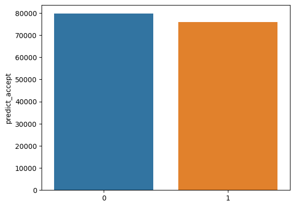

```python
sns.barplot(x=y_hyper.value_counts().index, y=y_hyper.value_counts())
```

The dataset is almost perfectly balanced. That was not the intention during data cleaning, but it's a happy little accident

### Exploring models to use

We created an optimizer that will try to find optimal parameters for the chosen algorithm.. it uses various types of CrossValidation implementations (GridSearch, Bayesian ... ) and it only supports 4 models, for now:

- RandomForestClassifier
- SVC
- XGBClassifier
- LogisticRegression

An exhaustive option would be to create all 4 models, tune them all, and them compare the winner of each type, but this is costly in terms of time (human and CPU time), so we will do something simpler:

- we will create a simple version of each, compare them all, and only perform hyper parameter tuning for the winner.

...

After a bit of time spent doing this, we have found:

- RandomForestClassifier - ✅
- SVC ❌ - too slow / did not converge (unsurprising, since it's not optimal for large datasets)
- XGBClassifier - ✅
- LogisticRegression ❌ - did not converge

With this, we will pick RandomForestClassifier and XGBClassifier, and use these

### Hyper parameter tuning

For hyperparameter tuning, we tried a few iterations, with each of these, and our custom AutoTuner (which uses BayesianCV under the hood.)

The performance was pretty bad, so I removed the code, but I wanted to leave a couple of sprinkles so the reader gets a general idea of the poor performance that the best model achieved.

```
rf_optimizer = optimize_utils.BayesCVOptimizer(RandomForestClassifier(), n_iter=10)
svc_optimizer = optimize_utils.BayesCVOptimizer(SVC(), n_iter=10)
xgb_classifier = optimize_utils.BayesCVOptimizer(XGBClassifier(), n_iter=100)
log_regressor = optimize_utils.BayesCVOptimizer(LogisticRegression(), n_iter=10)
```

```
Loading from cache [./cached/charts/part1_1_xgbc_first_tuning.png]
```

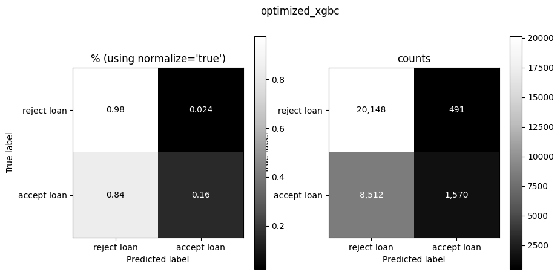

```python
@run
@cached_chart()
def part1_1_xgbc_first_tuning():
    # old code was here.. This is just to show the cached version of the performance.
    reminder = "do not run this. running this will accidentally delete the cached chart. This is just here to show how poor BayesianCV was"
    raise ValueError(reminder)
```

Out of the box and with basic tuning, we see that the model works sort of well.. Maybe a bit too conservative, but definitely leaning towards the "safe" side.

- On the true REJECT loan side:
  - Perfectly predicting REJECT loans (good true negatives)
  - Very low false positives: ~2%.
    - we want this number to be as small as possible, as we consider these loans to be too risky (we might lose money).
- On the true ACCEPT loan side:
  - The model is very conservative and only approving 16% of the loans it could be giving out.
  - This % is quite low (which results in a high the opportunity cost).
  - If we have a small cash flow, this might be enough.
  - But if we have an overabundance of cash, we could be approving more loans and significantly boosting our profits.

Overall, not a great model. We will look for better alternatives.

### Checking XGBClassifier with Optuna Hyperparameter Tuning

In this next section, we will pick the best performing model from the previous iteration and we will fine tune it using Optuna instead of BayesianCV

Some of the challenges I wanted to explore in this section were:

- How to use Optuna for hyperparameter tuning
- How to use Optuna's in a simulated "distributed" computing environment
  - to learn the tool
  - to reduce the training time
  - to better utilize my laptop's CPU
  - to practice with multi-thread/multi-process programming

```python
def fast_xgbc(best_params):
    """
    a version of this will be generalized and created in `optuna_utils.on_all_cores()` for future reuse
    """
    xgb_params = dict(best_params)
    xgb_params["n_jobs"] = -1
    return XGBClassifier(**xgb_params)
```

```python
from sklearn.model_selection import KFold
from sklearn.metrics import f1_score
import optuna


# This is a quick and dirty version of the function. A more long-term
# version will be created in `optuna_utils.optuna_optimize_model()` with long-term improvements.
# That one is the function that I will use for the rest of this project, and for
# future projects (if you see bugs/improvements for this one),
# check if the one in optuna_utils fixes it :)
def optuna_optimize_model(trial):
    """
    generates a new candidate from the provided trial config and
    evaluates their performane using 5 fold CrossVal.
    Default to using 5 fold, and F1 Score to measure performance.
    """
    model = optuna_utils.XgbClassifierCandidateProvider().provide(trial)

    kf = KFold(n_splits=5)
    scores = []

    X = X_df.to_numpy()
    y = y_df.to_numpy()

    for train_index, val_index in kf.split(X):
        X_train_kf, X_val_kf = (
            pd.DataFrame(np.array(X)[train_index], columns=X_df.columns),
            pd.DataFrame(np.array(X)[val_index], columns=X_df.columns),
        )
        y_train_kf, y_val_kf = (
            pd.Series(np.array(y)[train_index]),
            pd.Series(np.array(y)[val_index]),
        )
        model.fit(X_train_kf, y_train_kf)
        y_pred = model.predict(X_val_kf)
        score = f1_score(y_val_kf, y_pred)
        scores.append(score)

        # let's also try some Pruning action, to see if it speeds us up :)
        intermediate_result = -(sum(scores) / len(scores))
        trial.report(intermediate_result, step=len(scores))
        if trial.should_prune():
            raise optuna.TrialPruned()

    avg_score = -(sum(scores) / len(scores))
    return avg_score


def sprint1_launch_optuna_optimization():
    study = optuna_utils.parallelize_optuna(
        "part1_xgbc",
        n_processes=15,
        trials_per_process=25,
        objective=optuna_optimize_model,
    )


if optuna_utils.get_study("part1_xgbc"):
    print("Study already exists. Skipping")
else:
    slice_size = 100_000
    X_df = X_hyper[0:slice_size]
    y_df = y_hyper[0:slice_size]
    sprint1_launch_optuna_optimization()
```

```
Study already exists. Skipping
```

```
SELECT state, count(state), 100 * count(state) / 60
FROM main.trials
GROUP BY state
```

| state | count | % |
| --- | --- | --- |
| COMPLETE | 16 | 26 |
| FAIL (interrupted Ctrl+C) | 15 | 25 |
| PRUNED | 29 | 48 |

A few things to highlight from the hyperparameter tuning study by optuna:

(further tunings and studies were performed after this one, but I will leave this one documented: The conclusions are the same, only the timestamps/durations change. May this documentation be used to describe the logic behind all of them.

```
[I 2023-09-03 14:21:57,844] A new study created in RDB with name: part1_xgbc
[I 2023-09-03 14:21:57,924] Using an existing study with name 'part1_xgbc' instead of creating a new one.
[I 2023-09-03 14:21:58,463] Using an existing study with name 'part1_xgbc' instead of creating a new one.

[...]                                            <---- me going to get a well deserved lunch 🍲🍅🧀

[I 2023-09-03 14:23:39,773] Trial 1 finished with value: -0.6414860159860785 and parameters: {'n_jobs': 1, 'n_estimators': 150, 'max_depth': 2, 'learning_rate': 0.16369652531626333, 'subsample': 0.847005848658124, 'colsample_bytree': 0.49138613670197573, 'min_child_weight': 3, 'gamma': 0.9769740865215158, 'reg_alpha': 0.05112366072368842}. Best is trial 1 with value: -0.6414860159860785.

[...]                                            <---- a lot more training and pruning... 🔨 🕔

[I 2023-09-03 15:39:35,234] Trial 2 pruned.
[I 2023-09-03 15:39:40,090] Trial 20 pruned.
[I 2023-09-03 15:39:49,969] Trial 25 pruned.
[I 2023-09-03 15:39:52,366] Trial 18 finished with value: -0.6456761086785999 and parameters: {'n_jobs': 1, 'n_estimators': 440, 'max_depth': 2, 'learning_rate': 0.27385728365422674, 'subsample': 0.8971876898956417, 'colsample_bytree': 0.7191771785548249, 'min_child_weight': 2, 'gamma': 0.000556657476666451, 'reg_alpha': 0.02333365856940512}. Best is trial 16 with value: -0.6652197725635577.
[I 2023-09-03 15:39:58,305] Trial 14 finished with value: -0.6469423425783147 and parameters: {'n_jobs': 1, 'n_estimators': 340, 'max_depth': 6, 'learning_rate': 0.03578641658106952, 'subsample': 0.7570623277904541, 'colsample_bytree': 0.624693830356012, 'min_child_weight': 3, 'gamma': 0.3106507831505379, 'reg_alpha': 0.0009493952364002056}. Best is trial 16 with value: -0.6652197725635577.
[I 2023-09-03 15:40:05,467] Trial 26 pruned.
[I 2023-09-03 15:40:18,314] Trial 22 pruned.
[I 2023-09-03 15:40:36,815] Trial 27 pruned.
[I 2023-09-03 15:41:07,438] Trial 36 pruned.
[I 2023-09-03 15:41:17,800] Trial 35 finished with value: -0.6444080768470586 and parameters: {'n_jobs': 1, 'n_estimators': 50, 'max_depth': 4, 'learning_rate': 0.012773634072901703, 'subsample': 0.9889194347909753, 'colsample_bytree': 0.9899760671643933, 'min_child_weight': 1, 'gamma': 0.005101205859695762, 'reg_alpha': 0.3462496377819916}. Best is trial 16 with value: -0.6652197725635577.
[I 2023-09-03 15:41:26,694] Trial 21 pruned.
[I 2023-09-03 15:41:36,055] Trial 34 pruned.

[...]                                            <---- all trails end up in pruning... 🕔 seems like we've reached the bottom of the valley

[I 2023-09-03 15:50:15,099] Trial 85 pruned.
[I 2023-09-03 15:51:05,747] Trial 86 pruned.
[I 2023-09-03 15:51:50,845] Trial 87 pruned.
[W 2023-09-03 15:52:25,725] Trial 80 failed with parameters: {'n_jobs': 1, 'n_estimators': 560, 'max_depth': 6, 'learning_rate': 0.010338245932961343, 'subsample': 0.8479728521375465, 'colsample_bytree': 0.749254463910308, 'min_child_weight': 9, 'gamma': 0.00020151947595604367, 'reg_alpha': 0.03330298825131395} because of the following error: KeyboardInterrupt().

Ctrl+C
```

```python
optuna_utils.get_study("part1_xgbc").best_value
```

```
-0.6106646468786403
```

```python
@cached_with_pickle(1)
def part1_xgbclassifier_with_optuna():
    return optuna_utils.get_best_model("part1_xgbc", class_name="xgboost.XGBClassifier")


sprint1_xgbc_best_model = part1_xgbclassifier_with_optuna()
sprint1_xgbc_best_model.get_params()
```

```
{'base_score': 0.5,
 'booster': 'gbtree',
 'colsample_bylevel': 1,
 'colsample_bynode': 1,
 'colsample_bytree': 0.3053320716948362,
 'gamma': 0.00010166325897509975,
 'learning_rate': 0.001613822278052317,
 'max_delta_step': 0,
 'max_depth': 4,
 'min_child_weight': 2,
 'missing': None,
 'n_estimators': 170,
 'n_jobs': 16,
 'nthread': None,
 'objective': 'binary:logistic',
 'random_state': 0,
 'reg_alpha': 0.13530245885489614,
 'reg_lambda': 1,
 'scale_pos_weight': 1,
 'seed': None,
 'silent': None,
 'subsample': 0.6999834298669964,
 'verbosity': 1}
```

A couple of good things about this method:

- Saves time on future runs:
  - Even if the model was not persisted to disk using pickle (which it is), we'd still be able to access the parameters that our study encountered, even from day to the next; saving us hours of computation time.
- Saves time during training:
  - We can hyperparameter tune over different days, because we persist our trials.
  - We prune trials that do not show promising result, early! Saving valuable CPU and Dev time.
- Resumeable training means we don't have to do everything in one sitting:
  - We can tune a bit, kill it early and see if our model works well enough. If it doesn't, we can resume trials where we left them without having to restart.
- We use our fast_xgb() shortcut to make sure that our model (after tuning) uses all CPUs (tuning is done with 1 core per trial, but that's suboptimal for training/predicting)

```
Loading from cache [./cached/charts/sprint1_xgbc_optuna_tuned_chart_hp_hp.png]
```

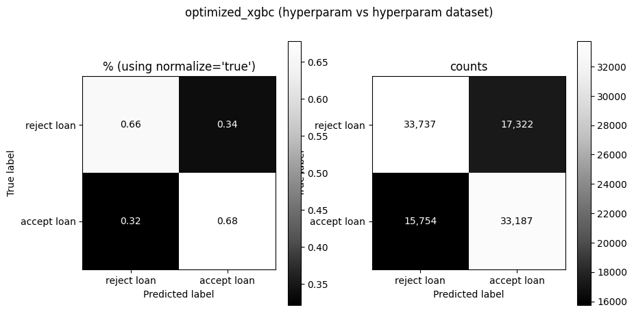

```python
@run
@cached_chart()
def sprint1_xgbc_optuna_tuned_chart_hp_hp():
    title = "optimized_xgbc (hyperparam vs hyperparam dataset)"
    X = X_hyper.sample(100_000)
    y = y_hyper.loc[X.index]
    sprint1_xgbc_best_model.fit(X, y)
    y_true = y
    y_pred = sprint1_xgbc_best_model.predict(X)
    return charts.conf_matrix(y_true, y_pred, title=title, normalize="true")
```

```
Loading from cache [./cached/charts/sprint1_xgbc_optuna_tuned_chart_train_train.png]
```

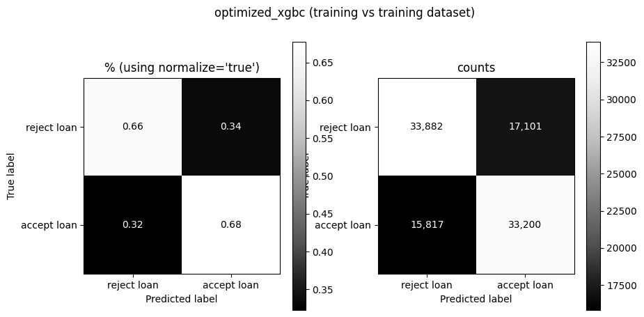

```python
@run
@cached_chart()
def sprint1_xgbc_optuna_tuned_chart_train_train():
    title = "optimized_xgbc (training vs training dataset)"
    X = X_train.sample(100_000)
    y = y_train.loc[X.index]
    sprint1_xgbc_best_model.fit(X, y)
    y_true = y
    y_pred = sprint1_xgbc_best_model.predict(X)
    return charts.conf_matrix(y_true, y_pred, title=title, normalize="true")
```

Conclusion:

```
Loading from cache [./cached/charts/sprint1_xgbc_optuna_tuned_chart_unseen_data.png]
```

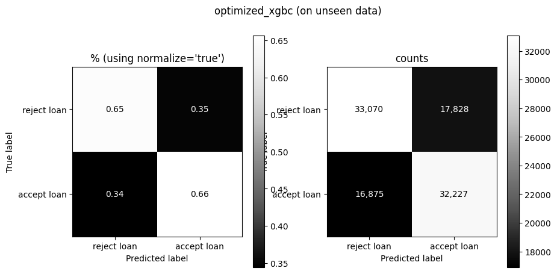

```python
@run
@cached_chart()
def sprint1_xgbc_optuna_tuned_chart_unseen_data():
    title = "optimized_xgbc (on unseen data)"
    X = X_hyper
    y = y_hyper
    sprint1_xgbc_best_model.fit(X, y)
    X_pred = X_train.sample(100_000)
    y_true = y_train.loc[X_pred.index]
    y_pred = sprint1_xgbc_best_model.predict(X_pred)
    return charts.conf_matrix(y_true, y_pred, title=title, normalize="true")
```

It behaves pretty well on unseen data (68% vs 66%), meaning there is no obvious overfitting.

### Scaling up to other models

The approach we found seems to work well, let's see if we can expand this to work for other binary classifiers, and assess their performance.

The rest of these trials will be different from the previous one:

- Less verbose (all of the logic has been cleaned up and moved to external modules for future reuse)
- More to the point (less chatty, more worky)
- We're moving from taking care of "pets" to taking care of "cattle" (if you are familiar with the [Pets-vs-Cattle DevOps metaphor](https://www.hava.io/blog/cattle-vs-pets-devops-explained))

#### XGBClassifier (but cleaner, this time)

```python
def xgbclassifier_model_optimized():
    X = X_hyper.sample(100_000)
    y = y_hyper.loc[X.index]

    candi = optuna_utils.XgbClassifierCandidateProvider()
    objective = optuna_utils.build_optuna_study(candi, X, y, scoring_function=f1_score)
    optuna_utils.parallelize_optuna(
        "sprint1_xgbclassifier", n_processes=15, trials_per_process=5, objective=objective
    )


if run_entire_notebook():
    xgbclassifier_model_optimized()
```

```
skipping optional operation
```

```python
optuna_utils.get_study("sprint1_xgbclassifier").best_value
```

```
0.6378499982643518
```

```python
optuna_utils.get_best_model("sprint1_xgbclassifier", class_name="xgboost.XGBClassifier")
```

```
XGBClassifier(colsample_bytree=0.41519791418346774, gamma=1.354333185728912e-05,
              learning_rate=0.03930776523307378, max_depth=4,
              min_child_weight=10, n_estimators=160, n_jobs=16,
              reg_alpha=3.9217906674274885e-05, subsample=0.6422000218792877)
```

#### Logistic Regression

```python
def logistic_regression_model_optimized():
    X = X_hyper.sample(100_000)
    y = y_hyper.loc[X.index]

    candi = optuna_utils.LogisticRegressionCandidateProvider()
    objective = optuna_utils.build_optuna_study(candi, X, y, scoring_function=f1_score)
    optuna_utils.parallelize_optuna(
        "sprint1_logistic_reg", n_processes=15, trials_per_process=25, objective=objective
    )


if run_entire_notebook():
    logistic_regression_model_optimized()
```

```
skipping optional operation
```

```python
optuna_utils.get_study("sprint1_logistic_reg").best_value
```

```
0.6294504187828588
```

```python
optuna_utils.get_best_model("sprint1_logistic_reg", class_name="xgboost.XGBClassifier")
```

```
XGBClassifier(C=515.6245955154467, fit_intercept=True, max_iter=141, n_jobs=16,
              penalty='l1', solver='liblinear')
```

#### Random Forests

```python
def random_forests_model_optimized():
    X = X_hyper.sample(100_000)
    y = y_hyper.loc[X.index]

    candi = optuna_utils.RandomForestCandidateProvider()
    objective = optuna_utils.build_optuna_study(candi, X, y, scoring_function=f1_score)
    optuna_utils.parallelize_optuna(
        "sprint1_random_forests",
        n_processes=15,
        trials_per_process=25,
        objective=objective,
    )


if run_entire_notebook():
    random_forests_model_optimized()
```

```
skipping optional operation
```

```python
optuna_utils.get_study("sprint1_random_forests").best_value
```

```
0.6463345022817526
```

```python
optuna_utils.get_best_model("sprint1_random_forests", class_name="xgboost.XGBClassifier")
```

```
XGBClassifier(criterion='entropy', max_depth=17, max_features='auto',
              min_samples_leaf=1, min_samples_split=9, n_estimators=973)
```

# Next steps

This is the end of sprint 1.

We are ready to jump into the next step: making predicting the loan's grade.

Jump into the notebook for sprint2, whenever you are ready